# Practical Machine Learning - Course Project Week 4

Prahlad

28/12/2019

## Executive Summary

Here the qualitative and quantitative data collected by wearable devices (belt, forarms, arm) for 6 participants has been analyzed for barbell lifts both correctly and incorrectly in 5 different ways. * A- as specified * B- streching Elbows to the front (wrong) * C- Lift dumbbell halfway (wrong) * D- Lower dumbbell halfway (wrong) * E- move hips to the front (wrong) Here first the quality of execution is analyzed and provide a feed back on correcting the mistakes. This was a controlled exercise. For more info refer http://groupware.les.inf.puc-rio.br/har.

The Model has been built to answer the above questions - Use the data base as input, clean the data, use the algorithms to build Training and Test data and then use the algorithms to do the predictions. Cross Validation is used as method for trainControl function.

## Input Data the files used are available at

The training data:

https://d396qusza40orc.cloudfront.net/predmachlearn/pml-training.csv

The test data:

https://d396qusza40orc.cloudfront.net/predmachlearn/pml-testing.csv

```r
training<- read.csv("pml-training.csv") # Training Data
testing<-read.csv("pml-testing.csv")  # Test Data

##Split the data into Training data set and Test data set.

inTrain<-createDataPartition(training$classe, p=.7, list=FALSE)
TrainSet<-training[inTrain,]
TestSet<-training[-inTrain,]
dim(TrainSet)
```

```
## [1] 13737   160
```

```r
dim(TestSet)
```

```
## [1] 5885  160
```

## NZV - near zero values check and remove

```
## [1] 13737   101
```

```
## [1] 5885  101
```

## Check and remove those data that contains more than 95% of NA. Filter these records.

```
## [1] 13737    59
```

```
## [1] 5885   59
```

## Remove the column 1 to 5 as these are not related to the model.

```r
TrainSet<- TrainSet[, -(1:5)]
TestSet<- TestSet[, -(1:5)]
dim(TrainSet)
```

```
## [1] 13737    54
```

```r
dim(TestSet)
```

```
## [1] 5885   54
```

## Model Random Forest

```r
set.seed(2345)
library(e1071)
controlRF<-trainControl(method="cv", number=3, verboseIter=FALSE)
modFitRandForest<- train(classe~., data=TrainSet, method="rf", trControl=controlRF)
modFitRandForest$finalModel
```

```
##
## Call:
##  randomForest(x = x, y = y, mtry = param$mtry)
##                Type of random forest: classification
##                      Number of trees: 500
## No. of variables tried at each split: 27
##
##         OOB estimate of  error rate: 0.23%
## Confusion matrix:
##      A    B    C    D    E  class.error
## A 3904    1    0    0    1 0.0005120328
## B    4 2650    3    1    0 0.0030097818
## C    0    5 2391    0    0 0.0020868114
## D    0    0    9 2242    1 0.0044404973
## E    0    1    0    5 2519 0.0023762376
```

## Predict Random Forest Model

```r
predRandForest<- predict(modFitRandForest, newdata=TestSet)
confMatRandForest<-confusionMatrix(predRandForest, TestSet$classe)
confMatRandForest
```

```
## Confusion Matrix and Statistics
##
##           Reference
## Prediction    A    B    C    D    E
##          A 1674    6    0    0    0
##          B    0 1133    3    0    0
##          C    0    0 1023    1    0
##          D    0    0    0  963    3
##          E    0    0    0    0 1079
##
## Overall Statistics
##
##                Accuracy : 0.9978
##                  95% CI : (0.9962, 0.9988)
##     No Information Rate : 0.2845
##     P-Value [Acc > NIR] : < 2.2e-16
##
##                   Kappa : 0.9972
##
##  Mcnemar's Test P-Value : NA
##
## Statistics by Class:
##
##                      Class: A Class: B Class: C Class: D Class: E
## Sensitivity            1.0000   0.9947   0.9971   0.9990   0.9972
## Specificity            0.9986   0.9994   0.9998   0.9994   1.0000
## Pos Pred Value         0.9964   0.9974   0.9990   0.9969   1.0000
## Neg Pred Value         1.0000   0.9987   0.9994   0.9998   0.9994
## Prevalence             0.2845   0.1935   0.1743   0.1638   0.1839
## Detection Rate         0.2845   0.1925   0.1738   0.1636   0.1833
## Detection Prevalence   0.2855   0.1930   0.1740   0.1641   0.1833
## Balanced Accuracy      0.9993   0.9971   0.9984   0.9992   0.9986
```

## Plot of Random Forest

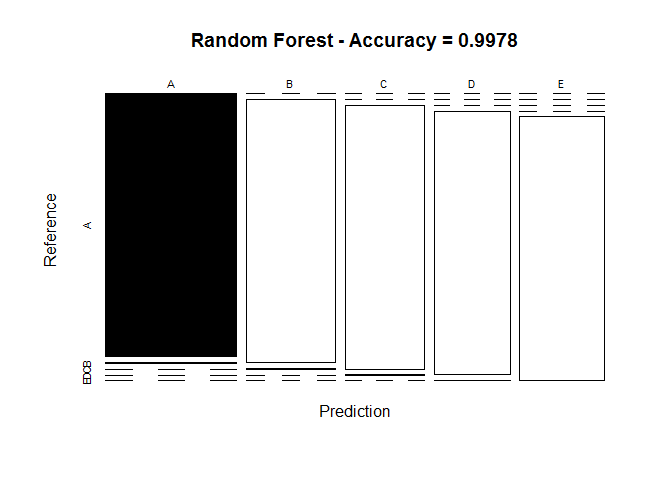

```r
plot(confMatRandForest$table, col=confMatRandForest$byClass, main= paste("Random Forest - Accuracy =" , round(confMatRandForest$overall["Accuracy"], 4)))
```

## Fit Model - GBM Model

```r
set.seed(999)
library(gbm)
controlGBM<- trainControl(method="repeatedcv", number=5, repeats=1)
modFitGBM<- train(classe~., data=TrainSet, method="gbm", trControl= controlGBM, verbose=FALSE)
modFitGBM$finalModel
```

```
## A gradient boosted model with multinomial loss function.
## 150 iterations were performed.
## There were 53 predictors of which 53 had non-zero influence.
```

## Check the Accuracy of Model - GBM - test data set

```r
predictGBM<- predict(modFitGBM, newdata=TestSet)
confMatGBM<-confusionMatrix(predictGBM, TestSet$classe)
confMatGBM
```

```
## Confusion Matrix and Statistics
##
##           Reference
## Prediction    A    B    C    D    E
##          A 1667   13    0    1    0
##          B    7 1111    6    8    5
##          C    0   15 1013   17    2
##          D    0    0    6  938    7
##          E    0    0    1    0 1068
##
## Overall Statistics
##
##                Accuracy : 0.985
##                  95% CI : (0.9816, 0.988)
##     No Information Rate : 0.2845
##     P-Value [Acc > NIR] : < 2.2e-16
##
##                   Kappa : 0.9811
##
##  Mcnemar's Test P-Value : NA
##
## Statistics by Class:
##
##                      Class: A Class: B Class: C Class: D Class: E
## Sensitivity            0.9958   0.9754   0.9873   0.9730   0.9871
## Specificity            0.9967   0.9945   0.9930   0.9974   0.9998
## Pos Pred Value         0.9917   0.9771   0.9675   0.9863   0.9991
## Neg Pred Value         0.9983   0.9941   0.9973   0.9947   0.9971
## Prevalence             0.2845   0.1935   0.1743   0.1638   0.1839
## Detection Rate         0.2833   0.1888   0.1721   0.1594   0.1815
## Detection Prevalence   0.2856   0.1932   0.1779   0.1616   0.1816
## Balanced Accuracy      0.9962   0.9850   0.9902   0.9852   0.9934
```

##Plot

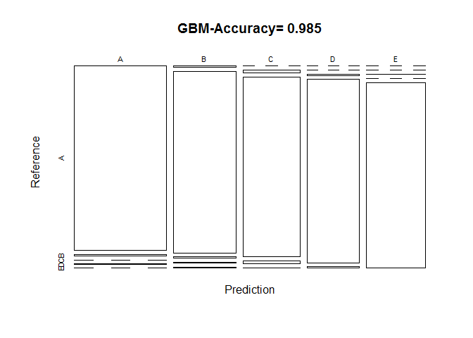

```r
plot(confMatGBM$table, col=confMatGBM$byClass, main= paste("GBM-Accuracy=", round(confMatGBM$overall["Accuracy"], 4)))
```

##Decision Tree Method

```r
decisionTreeMod<-train(classe~., method="rpart", data= TrainSet)
decisionTreePred<- predict(decisionTreeMod, newdata=TestSet)
confusionMatrix(TestSet$classe, decisionTreePred)
```

```
## Confusion Matrix and Statistics
##
##           Reference
## Prediction    A    B    C    D    E
##          A 1460   31  182    0    1
##          B  248  410  481    0    0
##          C  183   30  813    0    0
##          D  148  181  589    0   46
##          E   46   85  292    0  659
##
## Overall Statistics
##
##                Accuracy : 0.5679
##                  95% CI : (0.5551, 0.5806)
##     No Information Rate : 0.4005
##     P-Value [Acc > NIR] : < 2.2e-16
##
##                   Kappa : 0.4482
##
##  Mcnemar's Test P-Value : < 2.2e-16
##
## Statistics by Class:
##
##                      Class: A Class: B Class: C Class: D Class: E
## Sensitivity            0.7002  0.55631   0.3449       NA   0.9334
## Specificity            0.9437  0.85839   0.9396   0.8362   0.9183
## Pos Pred Value         0.8722  0.35996   0.7924       NA   0.6091
## Neg Pred Value         0.8516  0.93110   0.6822       NA   0.9902
## Prevalence             0.3543  0.12523   0.4005   0.0000   0.1200
## Detection Rate         0.2481  0.06967   0.1381   0.0000   0.1120
## Detection Prevalence   0.2845  0.19354   0.1743   0.1638   0.1839
## Balanced Accuracy      0.8220  0.70735   0.6423       NA   0.9259
```

##Plot Decisioon Tree

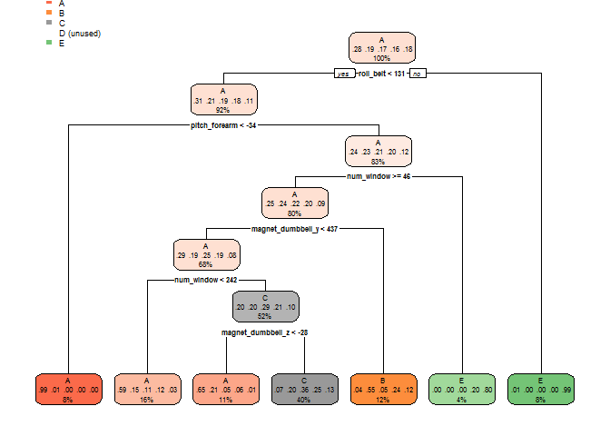

```r
rpart.plot(decisionTreeMod$finalModel)
```

## Final Prediction based on RF Test Data

```r
predictTEST<- predict(modFitRandForest, newdata= testing)
predictTEST
```

```
##  [1] B A B A A E D B A A B C B A E E A B B B
## Levels: A B C D E
```

##Results and Discussions The overall accuracy of Random Forest Model is better than GBM model. The RandomeForest Model is selected for the final prediction.

## References

Ugulino, W.; Cardador, D.; Vega, K.; Velloso, E.; Milidiu, R.; Fuks, H. Wearable Computing: Accelerometers’ Data Classification of Body Postures and Movements. Proceedings of 21st Brazilian Symposium on Artificial Intelligence. Advances in Artificial Intelligence - SBIA 2012. In: Lecture Notes in Computer Science. , pp. 52-61. Curitiba, PR: Springer Berlin / Heidelberg, 2012. ISBN 978-3-642-34458-9. DOI: 10.1007/978-3-642-34459-6_6. Cited by 2 (Google Scholar)

Read more: http://groupware.les.inf.puc-rio.br/har#ixzz69PPVYt9p